# IODS course project

Kisun Pokharel

# Tools and Methods for open and reproducible research

The first week of the course covered basic tools and requirements for the rest of the weeks. I practiced basics of R by completing a Data Camp exercise called [“R Short and Sweet”](https://www.datacamp.com/courses/r-short-and-sweet). In addition I brushed up git and rmarkdown by going through the first workshop as detailed below.

## Rstudio Exercise 1

1. I already had a github account and I just forked “IODS-project” from Tuomo Nieminen’s github.
2. I modified chapter1.Rmd file under IODS-project in Rstudio. Link to my IODS-project repository is [here](https://github.com/kisun/IODS-project).
3. I opened the index.Rmd file and added my name. I commited the change and pushed to my github.
4. I created a new Rmarkdown file with Rstudio. I wrote few sentences about the course and saved it as README.Rmd under IODS-project. The link to my course diary is [here](https://kisun.github.io/IODS-project/)
5. I replaced the default theme of my course diary web page with **Time Machine** theme.
6. I uploaded all the changes to GitHub.
7. I made sure that all changes could be seen.

Note1: Something that was not mentioned in the course that could be useful or could be included in future. Rstudio works hand-in-hand with github so R scripts or Rmd documents can be directly linked to github. The parent directory of the course (locally downloaded to the PC) can be imported as a github project that can be authorized by one’s username and password.

keywords: github, linux, rstudio, rmarkdown

# Regression and Model validation

During the second week of this course, we have been delving deeper into R and statistics. We learned about regression models and the application of R in statistical modeling. The datacamp exercises along with the two embedded videos provided good background on the topics. Chapter three from [“An Introduction to Statistical Learning with Applications in R”](http://www-bcf.usc.edu/~gareth/ISL/) covered in-depth topics in linear regression.

## RStudio Exercise 2

### Data Wrangling

After going through the study materials, I attempted the RStudio exercise. The first part of the exercise was related to data wrangling where a subset of table was generated from a table with raw data (observations). The R script used to create the table can be found [here](https://github.com/kisun/IODS-project/tree/master/data/create_learning2014.R).

### Analysis

The R script for this part is available [here](https://github.com/kisun/IODS-project/tree/master/data/analysis.R). The data used in this exercise comes from an international survey of approaches to learning conducted by Kimmo Vehkalahti. The survey was funded by Teachers’ Academy funding (2013-2015) and the data was collected during December 2014 to January 2015. The survey was conducted in Finland with an aim to understand the relationship between learning approaches and students’ achievements in an introductory statistics course. A total of 183 individuals were included in the survey where the students were assessed for three different studying approaches - surface approach, deep approach and strategic approach. Additional details about the survey can be found [here](http://www.slideshare.net/kimmovehkalahti/the-relationship-between-learning-approaches-and-students-achievements-in-an-introductory-statistics-course-in-finland). After preprocessing in data wrangling step, we read the data into R and applied regression models.

```r
lrn2014<-read.table("data/learning2014.csv")
str(lrn2014)
```

```
## 'data.frame':    166 obs. of  7 variables:
##  $ gender  : Factor w/ 2 levels "F","M": 1 2 1 2 2 1 2 1 2 1 ...
##  $ age     : int  53 55 49 53 49 38 50 37 37 42 ...
##  $ attitude: num  3.7 3.1 2.5 3.5 3.7 3.8 3.5 2.9 3.8 2.1 ...
##  $ deep    : num  3.58 2.92 3.5 3.5 3.67 ...
##  $ stra    : num  3.38 2.75 3.62 3.12 3.62 ...
##  $ surf    : num  2.58 3.17 2.25 2.25 2.83 ...
##  $ points  : int  25 12 24 10 22 21 21 31 24 26 ...
```

```r
dim(lrn2014)
```

```
## [1] 166   7
```

The final table used for analysis consist data including seven different variables and 166 individuals (see above). Among the variables, gender is a factor variable, age and points are integers whereas attitude, deep, stra and surf variables include float values.

```r
summary(lrn2014)
```

```
##  gender       age           attitude          deep            stra
##  F:110   Min.   :17.00   Min.   :1.400   Min.   :1.583   Min.   :1.250
##  M: 56   1st Qu.:21.00   1st Qu.:2.600   1st Qu.:3.333   1st Qu.:2.625
##          Median :22.00   Median :3.200   Median :3.667   Median :3.188
##          Mean   :25.51   Mean   :3.143   Mean   :3.680   Mean   :3.121
##          3rd Qu.:27.00   3rd Qu.:3.700   3rd Qu.:4.083   3rd Qu.:3.625
##          Max.   :55.00   Max.   :5.000   Max.   :4.917   Max.   :5.000
##       surf           points
##  Min.   :1.583   Min.   : 7.00
##  1st Qu.:2.417   1st Qu.:19.00
##  Median :2.833   Median :23.00
##  Mean   :2.787   Mean   :22.72
##  3rd Qu.:3.167   3rd Qu.:27.75
##  Max.   :4.333   Max.   :33.00
```

The number of females (n=110) in this survey is almost two times the number of males (n=56). The age of students ranged from 17 years up to 55 years.

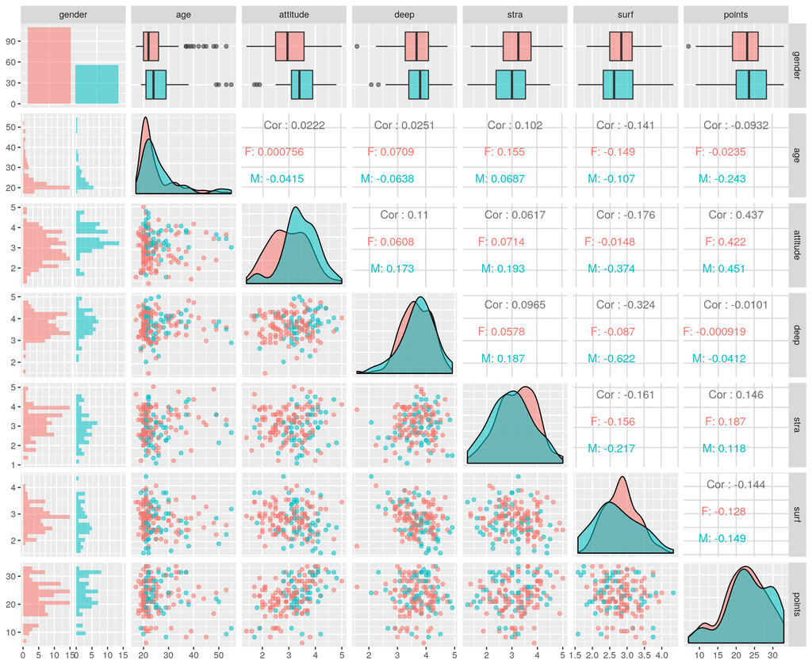

```r
plot_lrn2014<-ggpairs(lrn2014, mapping = aes(col=gender, alpha = 0.3), lower=list(combo = wrap ("facethist", bins = 20)))
plot_lrn2014
```

The graphical overview of the data is shown above. Here, the overall goal of the survey is to identify how age of the students, attitude towards learning and three different learning methods are contributing towards the final points. In general, attitude towards learning has the highest impact for overall outcome of the study (i.e points scored) whereas deep learning method do not have any impact.

The explanatory variables were selected based on the absolute correlation values. The three explanatory variables for exam points (top correlated variables, also shown in the plot above) are student’s attitude towards learning (attitude), learning strategy (stra) and surface learning approach (surf). The model based on three dependent variables on exam points has the maximum residual value of 10.9 and median of 0.5. Here, residual value is the remaining value after the predicted value is substracted by the observed value. The model summary showed that attitude is highly significant (Pr=1.93e-08) variable that affects the student’s exam points. On the other hand, learning strategy and surface learning are not significant variables (Pr>0.01).

```r
model<-lm(points ~ attitude + stra + surf, data = lrn2014)
summary(model)
```

```
##
## Call:
## lm(formula = points ~ attitude + stra + surf, data = lrn2014)
##
## Residuals:
##      Min       1Q   Median       3Q      Max
## -17.1550  -3.4346   0.5156   3.6401  10.8952
##
## Coefficients:
##             Estimate Std. Error t value Pr(>|t|)
## (Intercept)  11.0171     3.6837   2.991  0.00322 **
## attitude      3.3952     0.5741   5.913 1.93e-08 ***
## stra          0.8531     0.5416   1.575  0.11716
## surf         -0.5861     0.8014  -0.731  0.46563
## ---
## Signif. codes:  0 '***' 0.001 '**' 0.01 '*' 0.05 '.' 0.1 ' ' 1
##
## Residual standard error: 5.296 on 162 degrees of freedom
## Multiple R-squared:  0.2074, Adjusted R-squared:  0.1927
## F-statistic: 14.13 on 3 and 162 DF,  p-value: 3.156e-08
```

```r
model_sig<-lm(points ~ attitude, data = lrn2014)
summary(model_sig)
```

```
##
## Call:
## lm(formula = points ~ attitude, data = lrn2014)
##
## Residuals:
##      Min       1Q   Median       3Q      Max
## -16.9763  -3.2119   0.4339   4.1534  10.6645
##
## Coefficients:
##             Estimate Std. Error t value Pr(>|t|)
## (Intercept)  11.6372     1.8303   6.358 1.95e-09 ***
## attitude      3.5255     0.5674   6.214 4.12e-09 ***
## ---
## Signif. codes:  0 '***' 0.001 '**' 0.01 '*' 0.05 '.' 0.1 ' ' 1
##
## Residual standard error: 5.32 on 164 degrees of freedom
## Multiple R-squared:  0.1906, Adjusted R-squared:  0.1856
## F-statistic: 38.61 on 1 and 164 DF,  p-value: 4.119e-09
```

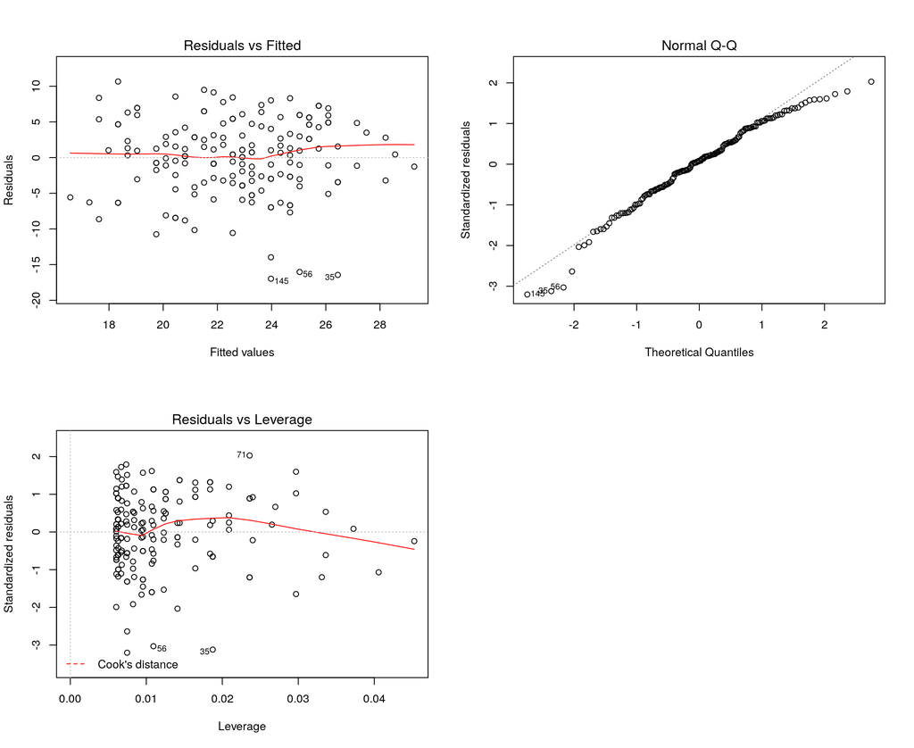

```r
par(mfrow = c(2,2))
plot(model_sig, which = c(1,2,5))
```

The three different diagnostic plots are generated above.The assumptions behind all three models is linearity and normality. Based on the above plots, we can conclude that the errors are normally distributed (clearly observed in q-q plot). Similarly, residual versus fitted model showed that the errors are not dependent on the attitude variable. Moreover, we can see that even two points (towards the right) have minor influence to the assumption in case of residual vs leverage model. All the models have adressed the outliers nicely. Thus, assumptions in all models are more or less valid.

# Logistic Regression

One way to move on from linear regression is to consider settings where the dependent (target) variable is discrete. This opens a wide range of possibilities for modelling phenomena beyond the assumptions of continuity or normality.

Logistic regression is a powerful method that is well suited for predicting and classifying data by working with probabilities. It belongs to a large family of statistical models called Generalized Linear Models (GLM). An important special case that involves a binary target (taking only the values 0 or 1) is the most typical and popular form of logistic regression.

We will learn the concept of odds ratio (OR), which helps to understand and interpret the estimated coefficients of a logistic regression model. We also take a brief look at cross-validation, an important principle and technique for assessing the performance of a statistical model with another data set, for example by splitting the data into a training set and a testing set.

The slides and videos related to logistic regression can be found below.  
[Video: Logistic regression: probability and odds](https://player.vimeo.com/video/202056054)  
[Video: Logistic regression: Odds ratios](https://player.vimeo.com/video/202056098)  
[Video: Cross-validation: training and testing sets](https://player.vimeo.com/video/202056141)  
[Slides: Logistic regression](https://tuomonieminen.github.io/Helsinki-Open-Data-Science/#/23)

After going through the videos, we practiced [DataCamp exercises on Logistic regression](https://campus.datacamp.com/courses/helsinki-open-data-science/logistic-regression?ex=1) and started to work on the workshop (RStudio Exercise 3.

## RStudio Exercise 3

### Data Wrangling

The data for Exercise 3 was downloaded from UCI Machine Learning Repository ([link](https://archive.ics.uci.edu/ml/datasets/Student+Performance)). The zipped file contained two tables, namely student-mat.csv and student-por.csv. In this data wrangling exercise, the main task was to join two data sets and create a data frame for logistic regression analysis. More detailed information about the data is present in the next section (Data Analysis) of this exercise. The R script associated with this exercise can be found [here](https://github.com/kisun/IODS-project/blob/master/data/create_alc.R)

### Data Analysis

The joined student alcohol consumption data that was created during wrangling exercise was read into R.

```r
alc<-read.table("data/alc.csv")
#head(alc)
colnames(alc)
```

```
##  [1] "school"     "sex"        "age"        "address"    "famsize"
##  [6] "Pstatus"    "Medu"       "Fedu"       "Mjob"       "Fjob"
## [11] "reason"     "nursery"    "internet"   "guardian"   "traveltime"
## [16] "studytime"  "failures"   "schoolsup"  "famsup"     "paid"
## [21] "activities" "higher"     "romantic"   "famrel"     "freetime"
## [26] "goout"      "Dalc"       "Walc"       "health"     "absences"
## [31] "G1"         "G2"         "G3"         "alc_use"    "high_use"
```

The data set in this exercise is a collection of information that is associated with student’s performance in two Portugese high schools. Two subjects - Mathematics (mat) and Portugese language (por) were choosen in this study. The findings from this study were published in the Proceedings of 5th FUture BUsiness TEChnology Conference (FUBUTEC 2008) during April, 2008 in Porto, Protugal([link](http://www3.dsi.uminho.pt/pcortez/student.pdf)). Altogether 33 attributes were assessed covering different aspects of student’s life. More detailed attribute information can be found [here](https://archive.ics.uci.edu/ml/datasets/Student+Performance)

Here, the main goal of the analysis is to study how alcohol consumption is associated with other aspects in student’s life. After going through the background information, it is a bit easier to identify interesting variables that could be related to alcohol consumption. Personally, I believe that the following are the four interesting variables that are associated with alcohol consumption:

**Weekly study time (studytime)** : In my opinion, if a student spends more time studying, he will have less time for alcohol consumption.

**Going out with friends (goout)** : In general, students go out with friends for parties and get-togethers. Attending such partiies and gatherings will lead higher alcohol consumption compared to those who do not participate in such activities.

**Number of school absences (absences)** : We can think of two reasons in terms of alcohol consumption and school absences. The main reason is that when a student consumes alcohol (especially during the evening), he/she will have lesser desire to go school next day (depends on the level of consumption). Another reason might be that a student is absent from class because he has plan to drink alcholic beverages.

**Quality of family relationships (famrel)** : I think the quality of family relationship will also affect student’s attitude towards alcohol consumption and the student who has bad family relationship may consume more alcohol compare to one who has better family relationship.

In the following section, we will see in details how my hypotheses are explained by the data. First, let’s summarise the subset of the table which includes the variables I have chosen.

```r
library(dplyr)
my_var<- c("studytime", "absences", "goout", "famrel", "high_use")

my_var_data <- select(alc, one_of(my_var))
str(my_var_data)
```

```
## 'data.frame':    382 obs. of  5 variables:
##  $ studytime: int  2 2 2 3 2 2 2 2 2 2 ...
##  $ absences : int  5 3 8 1 2 8 0 4 0 0 ...
##  $ goout    : int  4 3 2 2 2 2 4 4 2 1 ...
##  $ famrel   : int  4 5 4 3 4 5 4 4 4 5 ...
##  $ high_use : logi  FALSE FALSE TRUE FALSE FALSE FALSE ...
```

All my chosen variables have integer values whereas information about the alcohol consumption is logical i.e True or False. Moreover, the str function also revealed the dimension of the selected data i.e 382 observations for five variables. After getting the data types, we can proceed with summarizing the table as follows:

```r
summary(my_var_data)
```

```
##    studytime        absences        goout           famrel
##  Min.   :1.000   Min.   : 0.0   Min.   :1.000   Min.   :1.000
##  1st Qu.:1.000   1st Qu.: 1.0   1st Qu.:2.000   1st Qu.:4.000
##  Median :2.000   Median : 3.0   Median :3.000   Median :4.000
##  Mean   :2.037   Mean   : 4.5   Mean   :3.113   Mean   :3.937
##  3rd Qu.:2.000   3rd Qu.: 6.0   3rd Qu.:4.000   3rd Qu.:5.000
##  Max.   :4.000   Max.   :45.0   Max.   :5.000   Max.   :5.000
##   high_use
##  Mode :logical
##  FALSE:268
##  TRUE :114
##
##
##
```

We can have graphical representation of each of the variables as bar charts (see below).

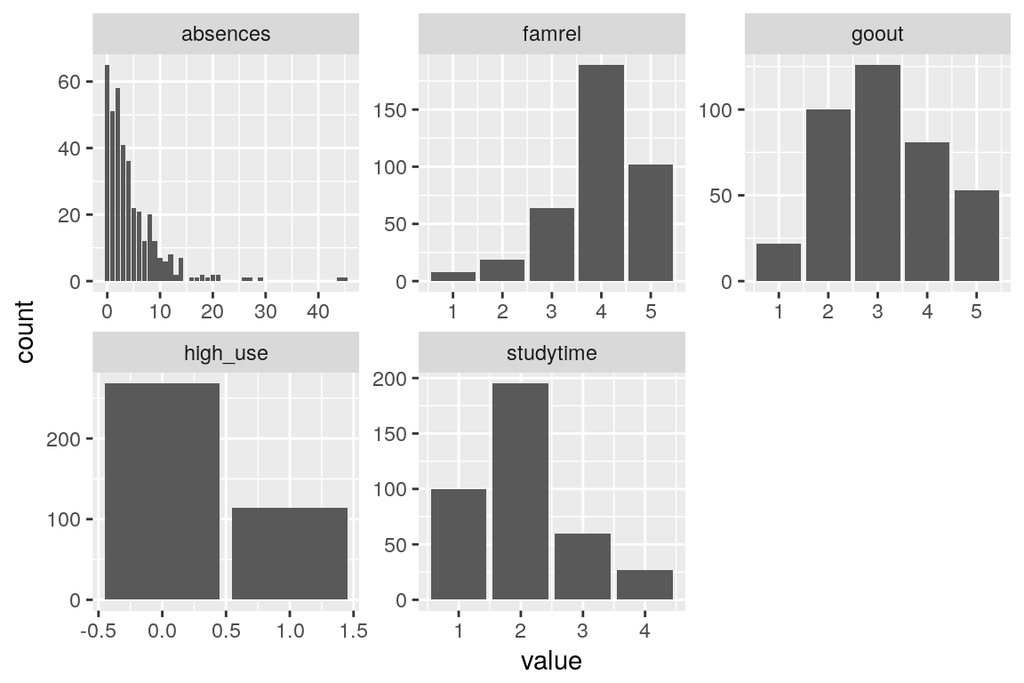

```r
library(tidyr)
library(ggplot2)


gather(my_var_data) %>% ggplot(aes(value)) + facet_wrap("key", scales = "free") + geom_bar()
```

The summary tables provide information for alcohol consumption in relation to the factors for each selected variables.

```r
t1 <- table("Study Time" = alc$studytime, "Alcohol Usage" = alc$high_use)
round(prop.table(t1, 1)*100, 1)
```

```
##           Alcohol Usage
## Study Time FALSE TRUE
##          1  58.0 42.0
##          2  69.2 30.8
##          3  86.7 13.3
##          4  85.2 14.8
```

```r
t2 <- table("Going Out" = alc$goout, "Alcohol Usage" = alc$high_use)
round(prop.table(t2, 1)*100, 1)
```

```
##          Alcohol Usage
## Going Out FALSE TRUE
##         1  86.4 13.6
##         2  84.0 16.0
##         3  81.7 18.3
##         4  50.6 49.4
##         5  39.6 60.4
```

```r
t3 <- table("Absences" = alc$absences, "Alcohol Usage" = alc$high_use)
round(prop.table(t3, 1)*100, 1)
```

```
##         Alcohol Usage
## Absences FALSE  TRUE
##       0   80.0  20.0
##       1   74.5  25.5
##       2   72.4  27.6
##       3   80.5  19.5
##       4   66.7  33.3
##       5   72.7  27.3
##       6   76.2  23.8
##       7   75.0  25.0
##       8   70.0  30.0
##       9   50.0  50.0
##       10  71.4  28.6
##       11  33.3  66.7
##       12  50.0  50.0
##       13  50.0  50.0
##       14  14.3  85.7
##       16   0.0 100.0
##       17   0.0 100.0
##       18  50.0  50.0
##       19   0.0 100.0
##       20 100.0   0.0
##       21  50.0  50.0
##       26   0.0 100.0
##       27   0.0 100.0
##       29   0.0 100.0
##       44   0.0 100.0
##       45 100.0   0.0
```

```r
t4 <- table("Family Relationship" = alc$famrel, "Alcohol Usage" = alc$high_use)
round(prop.table(t4, 1)*100, 1)
```

```
##                    Alcohol Usage
## Family Relationship FALSE TRUE
##                   1  75.0 25.0
##                   2  52.6 47.4
##                   3  60.9 39.1
##                   4  71.4 28.6
##                   5  76.5 23.5
```

Box plots provide more meaningful and summarized but more descriptive information for our variables as we can see the relationship of each four variables compared to alcohol consumption. Let’s look into more detail how the four variables I chose are affecting alcohol consumption in high school students using box plots.

```r
library(ggpubr)
```

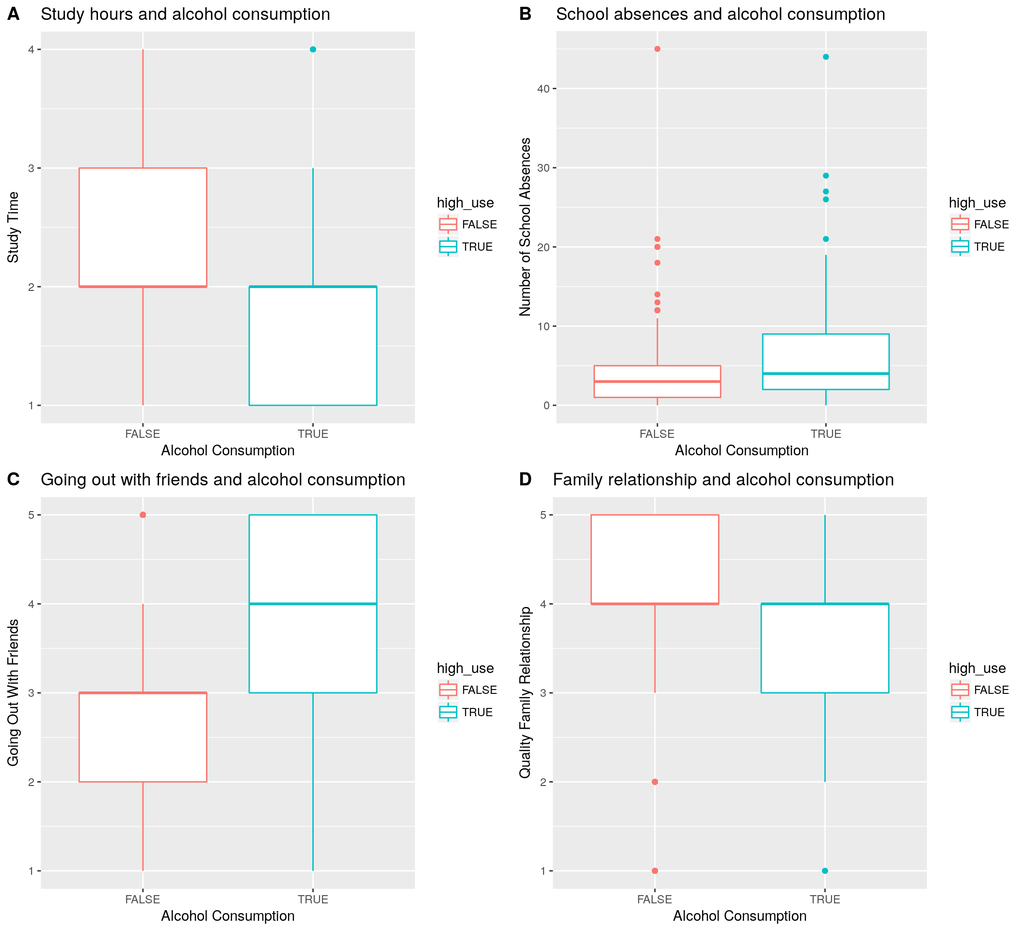

```r
g1 <- ggplot(alc, aes(x = high_use, y = studytime, col = high_use))

p1=g1 + geom_boxplot() + xlab("Alcohol Consumption")+ ylab("Study Time") + ggtitle("Study hours and alcohol consumption")

g2 <- ggplot(alc, aes(x = high_use, y = absences, col = high_use))

p2=g2 + geom_boxplot() + xlab("Alcohol Consumption")+ ylab("Number of School Absences")  + ggtitle("School absences and alcohol consumption")

g3 <- ggplot(alc, aes(x = high_use, y = goout, col = high_use))

p3=g3 + geom_boxplot() + xlab("Alcohol Consumption")+ ylab("Going Out With Friends")  + ggtitle("Going out with friends and alcohol consumption")
g4 <- ggplot(alc, aes(x = high_use, y = famrel, col = high_use))

p4=g4 + geom_boxplot() + xlab("Alcohol Consumption")+ ylab("Quality Family Relationship")  + ggtitle("Family relationship and alcohol consumption")

ggarrange(p1, p2, p3 , p4,  labels = c("A", "B", "C", "D"), ncol = 2, nrow = 2)
```

The four box plots above show how four of the chosen variables are associated with alcohol consumption. In each of the plots, x-axis shows the two different factors that measure the level of alcohol consumption i.e True for high consumption and False for low consumption and y-axis shows measurements for dependent variables i.e the four variables I have chosen. All of the box plots above show that what I hypothesized about the variables I selected in terms of alcohol consumption seem to be valid. We can see, they are valid but are these significantly valid observations? I will do a series of modeling and validations in the following sections.

**Logistic Regression**

Now we will do logistic regression where alcohol consumption (high_use) is target variable and four variables (studytime, goout, absences, famrel) I selected are the predictors.

```r
m<-glm(high_use ~ studytime + goout + absences + famrel, data = alc, family = "binomial")
summary(m)
```

```
##
## Call:
## glm(formula = high_use ~ studytime + goout + absences + famrel,
##     family = "binomial", data = alc)
##
## Deviance Residuals:
##     Min       1Q   Median       3Q      Max
## -1.8701  -0.7738  -0.5019   0.8042   2.5416
##
## Coefficients:
##             Estimate Std. Error z value Pr(>|z|)
## (Intercept) -1.28606    0.70957  -1.812  0.06992 .
## studytime   -0.55089    0.16789  -3.281  0.00103 **
## goout        0.75953    0.12041   6.308 2.82e-10 ***
## absences     0.06753    0.02175   3.104  0.00191 **
## famrel      -0.33699    0.13681  -2.463  0.01377 *
## ---
## Signif. codes:  0 '***' 0.001 '**' 0.01 '*' 0.05 '.' 0.1 ' ' 1
##
## (Dispersion parameter for binomial family taken to be 1)
##
##     Null deviance: 465.68  on 381  degrees of freedom
## Residual deviance: 384.07  on 377  degrees of freedom
## AIC: 394.07
##
## Number of Fisher Scoring iterations: 4
```

Among four variables, going out with friends (goout) is strongly coorelated (Pr = 2.82e-10) with alcohol consumption whereas quality of the family relationship (famrel) has comparatively lower impact towards alcohol consumption. Moreover, all four variables are significantly associated with alcohol consumption. Out of four variables, weekly study time (studytime) and the quality of family relationship (famrel) are inversely related to alcohol consumption. In other words, the more the number of hours spent in studying and the better the quality of the samily relationship, the lower the alcohol consumption. On the other hand, the number of school absences and frequency of going out with friends is positively correlated with alcohol consumption. This means that, if a student has higher number of school absences and goes out frequently with friends, his alcohol consumption is higher.

I will further delve into my model by evaluating it in terms of coefficients, odds ratio and confidence intervals.

```r
Coef<-coef(m)
OR<-Coef %>% exp
CI<-confint(m) %>% exp
cbind(Coef, OR, CI)
```

```
##                    Coef        OR      2.5 %    97.5 %
## (Intercept) -1.28606058 0.2763573 0.06723596 1.0961732
## studytime   -0.55089391 0.5764343 0.41040872 0.7941804
## goout        0.75953025 2.1372720 1.69853389 2.7261579
## absences     0.06753071 1.0698631 1.02591583 1.1187950
## famrel      -0.33699130 0.7139151 0.54460646 0.9331198
```

**Exploring predictive power of the model**

To get insight into the predictive power of my model, I will compare model’s prediction with the probability of actual vaules.

```r
 #predict the probability

 pred_prob <- predict(m, type = "response")

 #add predicted probabilities and mutate the model
 alc<-mutate(alc, probability = pred_prob)
 #we will use the probability to validate the probabilities of choses four variables
 alc<-mutate(alc, prediction = probability > 0.5)
 table(high_use = alc$high_use, prediction = alc$prediction)
```

```
##         prediction
## high_use FALSE TRUE
##    FALSE   242   26
##    TRUE     65   49
```

```r
#first we need to define loss function
LF<-function(class, prob){
  n_wrong <- abs(class - prob) > 0.5
  mean(n_wrong)
}
#now we compute the average number of wrong predictions
LF(alc$high_use, alc$prob)
```

```
## [1] 0.2382199
```

Now we can say that up to 24% of the predictions made by my model are false.

**Cross Validation**

Here we will perform 10-fold cross validation of our model

```r
#load required library
library(boot)

CV<-cv.glm(data = alc, cost = LF, glmfit = m, K = 10 )
#finally look at the average number of wrong predictions
CV$delta[1]
```

```
## [1] 0.2408377
```

# Clustering and Classification

The list of materials and links related to clustering and classification can be found below.  
[course slides by Emma Kämäräinen](https://tuomonieminen.github.io/Helsinki-Open-Data-Science/#/41)  
[DataCamp exercise](https://campus.datacamp.com/courses/helsinki-open-data-science/clustering-and-classification?ex=1)

## RStudio Exercise 4

**Additional links (also included in the course slides)**  
[Blog post by Jason Browniee on LDA](https://machinelearningmastery.com/linear-discriminant-analysis-for-machine-learning/)  
[R-bloggers post on LDA](https://www.r-bloggers.com/computing-and-visualizing-lda-in-r/) [R-bloggers post on K Means Clustering in R](https://www.r-bloggers.com/k-means-clustering-in-r/)